# Discovery, automation/scripting and integration of EPOS data and services Basic workflows in JupyterLab

Henning Lorenz  
Uppsala University, Sweden  
henning.lorenz@geo.uu.se

Used sources: General Python documentation, module documentation/tutorials, diverse web fora (untracked)

## Purpose of this notebook and content:

This notebook demonstrates multidisciplinary interaction with diverse EPOS data services, data integration and simple visualisation, using data from TCS Geological Information and Modelling, GNSS data, and Seismology. It starts from scratch with installing Jupyter Lab and setting up the notebook. You can also jump directly to the demonstration case. The topics are:

**The Basics**

- Summary of the basic setup of JupyterLab
- Basic useful modules

**Data and Data Transfer**

- How to interface with EPOS Services
  - Data, metadata and related services
  - Interacting with the EPOS data portal and services in JupyterLab
- How to read the data
  - Data formats
  - Standards

**What to do with the data**

- Interacting with services and data
- Processing and visualisation

**Demonstration case**

- Interacting with services and data

The Basics

## Summary of the basic setup of JupyterLab: (Assuming that Python runs under the operating system, assuming here Linux/Ubuntu.)

#### Install python virtual environments

```
sudo apt install python3-venv
```

#### Create a python virtual environment (If you are on a virtual machine, like WSL, the python virtual environment has to be on the Linux file system!)

```
python -m venv <your-environment-name>
```

#### Create a working folder for JupyterLabs (If you are on a virtual machine, like WSL, this folder can be anywhere, also in mounted file systems, like that of the host.)

```
mkdir <your-environment-name>/projects
```

#### Go to the working folder and start your virtual environment

```
cd <your-environment-name>/projects
source ../bin/activate
```

Check that the command prompt starts with (<name>) of the virtual environment, which indicates that it is running.

#### Update the pip package manager to the latest version

This regards the package manager of your virtual environment. Thus, it is important to activate the virtual environment before updating!

```
python -m pip install --upgrade pip
```

#### Install JupyterLab and all modules needed for this notebook

```
pip install jupyter scikit-image owslib pyproj pprintpp obspy cartopy folium mpld3 geopandas
```

#### Copy this notebook to the new folder, then start JupyterLab and open the notebook

## Some basic modules that are good to remember:

| **os** | Provides usage of operating system dependent functionality, e.g. `os.path()` to manipulate paths |
| --- | --- |
| **warnings** | Handles warning and error messages, e.g. suppress warnings that interfere with your work with `warnings.simplefilter("ignore")` |
| **re** | Provides regular expression matching operations similar to those found in Perl - use https://regexr.com/ or similar for testing filters |
| **math** | Provides access to the mathematical functions defined by the C standard |
| **pprint** | Pretty printing of data structures |
| **pprintpp** (pp-ez) | Another pretty-printer for data structures *(pip install pp-ez)* |

Sometimes, JupyterLab recogises modules that are installed while it is running, sometimes you have to restart.

## Remember: Your best friend is the documentation!

### For core modules: [https://docs.python.org/3/library/<module-name>.html](https://docs.python.org/3/library/%3Cmodule-name%3E.html)

### For projects (modules installed with pip): [https://pypi.org/project/<project-name>/](https://pypi.org/project/%3Cproject-name%3E/)

### For basics, look at https://www.w3schools.com/python

### Scientific modules and web services often have dedicated tutorials

## Remember as well: Most problems were encountered and solved before!

### Search dedicated web-fora, e.g. [Python Forum](https://python-forum.io/)

### Search the web! (Reddit, stackoverflow, ...)

### Ask your preferred AI model.

Data and data transfer

How to interface with EPOS services

How to interface with EPOS services  
Data, metadata and related services

Metadata/Metainformation  
→ Information about Data.

- In the strict IT definition, it describes only the form of data (data sets, data services).
- In the scientific context, it is often used as description for "something" that provides context to the scientific data set.  
  → According to the IT definition, the scientific metadata are data.

"Discovery data" *(informal)*  
→ Data that provide essential information about a data set or an object,  
allowing a user to decide whether the instance in question is relevant for a certain purpose or not.

- Related to the scientific definition of metainformation.
- Most of what we see in the EPOS portal falls in this category.
- A similar concept as IUGS CGI/OGC standards (GeoSciML) Portrayal/Lite

Data/data sets  
→ The scientific data.

- What it is all about.

How to interface with EPOS services  
Interacting with the [EPOS data portal](https://www.ics-c.epos-eu.org/) in JupyterLab (JL)

**Distinct discovered data sets**  
→ You know exactly what you want and proceed to processing/visualisation.

- ICS-D: Add the filtered service to your "Favourites" in the portal. The data set will be part of the generated JL.
- Any JL: In the "Download" pop-up window, use the HTML link to the data set.  
  Then you have to (down)load the data set in JL.

**Web services and APIs, automatisation**  
→ You use the portal for exploring available content, but interface services in JL, to establish  
workflows for repeated task or for easy tuning of paramenters in the data discovery.

- ICS-D: Add the filtered service to your "Favourites" in the portal.
- Any JL: **In the "Download" pop-up window, use the HTML link to the "raw service response".**

**Any combination of the above**  
→ Use the EPOS services how they best fit your task. Integrate your local data in the processing.

How to interface with EPOS services in Python  
Interaction with standardised services

### General HTTP requests *(data set download and all services/APIs)*

**urllib** - `urllib.request()` for opening and reading URLs (`urllib.parse()` for parsing URLs)

**requests** - User friendly handling of HTTP requests *(pip install requests)*

### Open Geospatial Consortium (OGC) web services (OWS) *some services are also ISO standard*

**OWSLib** - Facilitates the interaction with OWS like WFS, WMS, OGC API, and many more *(pip install OWSLib)*  
→ [Homepage](https://www.osgeo.org/projects/owslib/)  
→ [Documentation](https://owslib.readthedocs.io)  
→ [Mailing list](https://lists.osgeo.org/mailman/listinfo/owslib-users)

How to interface with EPOS services in Python  
Other modules that facilitate data access and processing/visualisation

### TCS Seismology

**ObsPy** - A Python framework for Seismology *(pip install obspy)*  
"ObsPy is an open-source project dedicated to provide a Python framework for processing seismological data. It provides parsers for common file formats, clients to access data centers and seismological signal processing routines which allow the manipulation of seismological time series."  
→ [Module page](https://pypi.org/project/obspy/)  
→ [Homepage](https://www.obspy.org)  
→ [Documentation](https://docs.obspy.org/)  
→ [Forum](https://discourse.obspy.org/)

**EMSC**: scripts available at [Github](https://github.com/EMSC-CSEM/webservices101)

### TCS GNSS Data and Products

**Pyglass** - Python command line tool to query a GLASS server *(no pip install, pip would install a different package with the same name)*  
→ [GitLab](https://gitlab.com/gpseurope)

**gnss-lib-py** - Python tool for parsing, analyzing, and visualizing Global Navigation Satellite Systems (GNSS) data and state estimates *(pip install gnss-lib-py)*  
→ [Module page](https://pypi.org/project/gnss-lib-py/)  
→ [GitHub](https://github.com/Stanford-NavLab/gnss_lib_py)  
→ [Documentation](https://gnss-lib-py.readthedocs.io/en/latest/)

How to interface with EPOS services in Python  
Other modules that facilitate data access and processing/visualisation

### TCS Geomagnetic Observations

**GeomagPy** - A Python package for analysing and displaying geomagnetic data *(pip install geomagpy)*  
"MagPy provides tools for geomagnetic data analysis with special focus on typical data processing routines in observatories. MagPy provides methods for data format conversion, plotting and mathematical procedures with specifically geomagnetic analysis routines such as basevalue and baseline calculation and database handling."  
→ [Module page](https://pypi.org/project/geomagpy)  
→ [GitHub](https://github.com/geomagpy/magpy)

**MTpy-v2**: A Python Toolbox for working with Magnetotelluric (MT) Data *(pip install mtpy-v2)*  
"mtpy provides tools for working with magnetotelluric (MT) data... a central data type that can hold transfer functions and then read/write to your modeling program, plot, and analyze your data."  
→ [Module page](https://pypi.org/project/mtpy-v2/)  
→ [GitHub](https://github.com/MTgeophysics/mtpy-v2)  
→ [Documentation](https://mtpy-v2.readthedocs.io)

Data and data transfer

How to read the data

How to read the data  
ASCII/UTF-8 vs binary data formats

- Python can open and read any ASCII/UTF-8 encoded file to a variable. However, it might be difficult to interact with the data in the file.
- Binary files are notorously difficult to handle if no modules/libraries exist for accessing the data.

→ Check the modules listed under services (above).

How to read the data  
Community standards

→ Check the modules listed under services (above).  
**Obspy** to interact with the seismic data formats,  
**Pyglass** and **gnss-lib-py** for RINEX data,  
**GeomagPy** and **MTpy-v2** for geomagnetic data.

How to read the data  
Standards/Universal data formats

### JSON

**json** - JSON encoder and decoder

### XML

**xml** - Collection of XML modules, of which xml.etree.ElementTree is the XML processor  
**lxml** - User friendly third-party XML processor: lxml.etree *(pip install lxml)*

### CSV

**csv** - CSV file reading and writing

### TIFF, GeoTIFF

**Pillow** - Image import and processing (a Python Imaging Library fork) *(pip install pillow)*  
**geotiff** - Reading and writing geotiff files without using GDAL *(pip install geotiff)*  
**GDAL** - GDAL (Geospatial Data Abstraction Library) support for Python *(pip install gdal)* [regard this as the universal geospatial multi-tool]  
→ [Module page](https://pypi.org/project/GDAL/)  
→ [Homepage](https://www.osgeo.org/projects/gdal/)  
→ [GDAL Documentation](https://gdal.org/en/stable/)

### netCDF (also HDF5!)

**netCDF4** - Provides an object-oriented python interface to the netCDF version 4 library (on top of HDF5) *(pip install netCDF4)*  
→ Search the software repository! Plenty of modules for universal and also very specific tasks (e.g. converters, extractors, ...)

How to read the data  
Proprietary data formats

Good luck!

### MatLab

MatLab files can often be read by the open source alternatives GNU Octave and Scilab.

- If you have a MatLab licence:  
  Use **"MATLAB Engine API for Python"** to call MatLab.
- Try with GNU Octave **oct2py** - 'Python to GNU Octave bridge --> run m-files from python.' *(pip install oct2py)*
- Try with Scilab scilab2py - The Python to Scilab bridge is hopelessly outdated.
- **dedicated Jupyter Python kernels**
  - **octave-kernel** - A Jupyter kernel for GNU Octave *(pip install octave-kernel)*
  - **scilab-kernel** - A Jupyter kernel for Scilab *(pip install scilab-kernel)*
  - and others

### Other formats

- Search the Python module repository
- Search the web

What to do with the data in Python?

Put them in variables

What to do with the data in Python  
Put them in variables

Read entire data set to a variable  
→ Choose a suitable function or module for the purpose!

- Open/read ASCII, TIFF, etc. files to variables (e.g. `f = open("somefile.asc")`)
- Interface a web service and read the response into a variable

Use arrays to structure your data

Indexed array: Python "list" - has a numeric index starting with 0

```python
indexed_array = ["seismology", "GNSS", "Boreholes"]

print(indexed_array[0])
```

```
seismology
```

```python
print(indexed_array[1])
```

```
GNSS
```

```python
print(indexed_array[2])
```

```
Boreholes
```

```python
indexed_array.append("Maps")
print(indexed_array)
```

```
['seismology', 'GNSS', 'Boreholes', 'Maps']
```

```python
indexed_array.append(["Volcano", "Observations"])
print(indexed_array)
```

```
['seismology', 'GNSS', 'Boreholes', 'Maps', ['Volcano', 'Observations']]
```

Associative array: Python "dictionary" - key → value

```python
associative_array = {'topic': "geology", 'feature': "borehole", 'country': "Spain"}
```

```python
print(associative_array['feature'])
```

```
borehole
```

```python
associative_array["depth_m"] = 2312
print(associative_array)
```

```
{'topic': 'geology', 'feature': 'borehole', 'country': 'Spain', 'depth_m': 2312}
```

```python
associative_array['purpose'] = ["basic research", "ore exploration"]
associative_array['driller'] = {'period_1': "driller1", 'period2': "driller2"}
print(associative_array)
```

```
{'topic': 'geology', 'feature': 'borehole', 'country': 'Spain', 'depth_m': 2312, 'purpose': ['basic research', 'ore exploration'], 'driller': {'period_1': 'driller1', 'period2': 'driller2'}}
```

- multidimensional array - multiple levels of lists and/or dictionaries
- other usful types exist, like set (unordered list of unique values) - please refer to the documentation

NumPy - Arrays as objects

→ Class and Object?

```python
# import numpy
import numpy as np
# scikit-image scientific image processing, here for demonstration
from skimage import io
# glob unix path handler
import glob

files = glob.glob('data/teststack/*.tiff')

load = []
for file in files:
    load.append(io.imread(file))
stack = np.asarray(load)
```

```python
stack.shape
```

```
(0,)
```

```python
dir(stack)
```

[output not shown]

[output cut: 114 more lines]

```
 'sort',
 'squeeze',
 'std',
 'strides',
 'sum',
 'swapaxes',
 'take',
 'to_device',
 'tobytes',
 'tofile',
 'tolist',
 'trace',
 'transpose',
 'var',
 'view']
```

```python
stack.view()
```

```
array([], dtype=float64)
```

What to do with the data in Python?

Process and visualise

What to do with the data in Python  
Process and visualise

Array manipulation and array computation

- Use basic Python functions to sort, append and otherwise manipulate lists and dictionaries (please refer to the documentation)
- **NumPy** - Scientific computing for Python *(pip install numpy)*  
  Use the NumPy array class instead of lists and dictionaries. NumPy provides comprehensive functionality for array computing.  
  → [Module page](https://pypi.org/project/numpy/)  
  → [Homepage](https://numpy.org/)  
  → [Documentation](https://numpy.org/doc/stable/)  
  → [Mailing list](https://mail.python.org/mailman3/lists/numpy-discussion.python.org/)

What to do with the data in Python  
Process and visualise

Calculation and computation

- **math** - Mathematical functions as defined in the C standard.
- **NumPy** - Scientific computing for Python *(pip install numpy)*
- **Pandas** - Python Data Analysis Library *(pip install pandas)*  
  "Pandas is a Python package that provides fast, flexible, and expressive data structures ... high-level building block for doing practical, real world data analysis in Python." Pandas uses a specific data class (DataFrame) to manipulte data efficiently.  
  → [Module page](https://pypi.org/project/pandas/)  
  → [Homepage](https://pandas.pydata.org/)  
  → [Documentation](https://pandas.pydata.org/docs/)  
  → [Forum](https://https://stackoverflow.com/questions/tagged/pandas)
- See **"Python for Data Analysis, Open Edition"** by Wes McKinney  
  → [3rd edition](https://wesmckinney.com/book/)
- The thematic packages discussed before may implement processing functionality!

What to do with the data in Python  
Process and visualise

Visualisation

- **MatPlotLib** - Static, animated, and interactive visualizations in Python *(pip install matplotlib)*  
  "Matplotlib produces publication-quality figures in a variety of hardcopy formats and interactive environments across platforms."  
  → [Module page](https://pypi.org/project/matplotlib/)  
  → [Homepage](https://matplotlib.org/)  
  → [Documentation](https://matplotlib.org/stable/users/index)  
  → [Forum](https://discourse.matplotlib.org/)
- **plotly** - Interactive data visualisation for Python *(pip install plotly)*  
  Builds on JavaScript plotly.js.  
  → [Module page](https://pypi.org/project/plotly/)  
  → [Documentation](https://plotly.com/python/)  
  → [Forum](https://community.plotly.com/c/plotly-python)

What to do with the data in Python  
Process and visualise

Geospatial data

- **GeoPandas** - Provides a high-level interface for geospatial data *(pip install geopandas)*  
  "GeoPandas is an open source project to make working with geospatial data in python easier. GeoPandas extends the datatypes used by pandas to allow spatial operations on geometric types."  
  → [Module page](https://pypi.org/project/geopandas/)  
  → [Homepage](https://geopandas.org/en/stable/)  
  → [Documentation](https://geopandas.org/en/stable/docs.html)
- **folium** - Webmapping with Python *(pip install folium)*  
  Builds on JavaScript Leaflet.js.  
  → [Module page](https://pypi.org/project/folium/)  
  → [Homepage](https://python-visualization.github.io/folium/latest/)  
  → [GitHub](https://github.com/python-visualization/folium)

What to do with the data in Python  
Process and visualise

Modelling

- **SimPEG** - An open source python package for simulation and gradient based parameter estimation in geophysical applications. *(pip install simpeg)*  
  Geophysical methods, forward simulations, inversion.  
  → [Module page](https://pypi.org/project/simpeg/)  
  → [Homepage](https://simpeg.xyz/)  
  → [Documentation](https://docs.simpeg.xyz/latest/)  
  → [GitHub](https://github.com/simpeg/simpeg)  
  → [Forum](https://simpeg.discourse.group/)
- **fatiando a terra** - Open-source library for modeling and inversion in geophysics *(pip install fatiando)*  
  Data processing, modelling, and inversion across the Geosciences.  
  → [Module page](https://pypi.org/project/fatiando/)  
  → [Homepage](https://www.fatiando.org)  
  → [Documentation](https://www.fatiando.org/learn/)  
  → [GitHub](https://github.com/fatiando)  
  → [Forum](https://github.com/orgs/fatiando/discussions)

Interacting with services and data

The basics

Interacting with services and data  
The basics

Directly accessing content over HTTP and read the data  
This could be a discrete file discovered through EPOS or any service response (whatever the HTTP request delivers, 1:1)

**requests**

```python
# import the requests module
import requests

# load the file via HTTP to a variable and print it - here a specific geomagnetic field modelling result
target = "https://geomag.bgs.ac.uk/web_service/GMModels/igrf/13?latitude=0&longitude=0&altitude=0&date=2020-01-01&format=txt"
data = requests.get(target)

print(data.text) # this is content in a Python object
# --> work with the data in the Python object, use a suitable module for the data type
```

```
Geomagnetic field model result:
    Model: igrf
    Revision: 13
    Date: 2020-01-01
    Coordinates:
        Latitude (deg north): 0
        Longitude (deg east): 0
        Altitude: 0.00 km
    Field Value:
        Total Intensity (nT):      31936
        Declination (deg east):    -4.654
        Inclination (deg down):    -30.093
        North Intensity (nT):      27540
        East Intensity (nT):       -2242
        Vertical Intensity (nT):   -16012
        Horizontal Intensity (nT): 27631
    Secular Variation:
        Total Intensity (nT/y):      -0.6
        Declination (arcmin/y east): 10.1
        Inclination (arcmin/y down): -3.0
        North Intensity (nT/y):      -7.9
        East Intensity (nT/y):       81.8
        Vertical Intensity (nT/y):   -23.7
        Horizontal Intensity (nT/y): -14.5
```

**urllib**

```python
# import the urllib module
import urllib

# load the file via HTTP to a variable and print it - here a specific geomagnetic field modelling result
target = "https://geomag.bgs.ac.uk/web_service/GMModels/igrf/13?latitude=0&longitude=0&altitude=0&date=2020-01-01&format=txt"
with urllib.request.urlopen(target) as response:
    data = response.read()

print(data) # this is content of the variable
# --> work with the data in the variable, use a suitable module for the data type
```

```
b'Geomagnetic field model result:\n    Model: igrf\n    Revision: 13\n    Date: 2020-01-01\n    Coordinates:\n        Latitude (deg north): 0\n        Longitude (deg east): 0\n        Altitude: 0.00 km\n    Field Value:\n        Total Intensity (nT):      31936\n        Declination (deg east):    -4…
```

Interacting with services and data  
The basics

Directly accessing content over HTTP and read the data  
What about compressed data, e.g zip-archives?

```python
# import the zipfile and os modules
import zipfile
import os

# load the file via HTTP to a data directory - here a specific geomagnetic field modelling result
target = "https://download.pangaea.de/dataset/922705/files/Glacially-Induced_Faults.zip" # a data set on the PANGAEA data repository
urllib.request.urlretrieve(target, './data/Glacially-Induced_Faults.zip')

print(os.listdir('./data/'))

# If this cell returns a "HTTP Error 503: Service Unavailable", this is due to a timeout.
# When a data set is not requested for some time, it might not be readily available but has to be fetched from storage.
# Try again afters some time.
```

```
['Glacially-Induced_Faults.zip', '.ipynb_checkpoints']
```

```python
# unzip the file to disk
with zipfile.ZipFile('./data/Glacially-Induced_Faults.zip', 'r') as unzip:
    unzip.extractall(path='./data')

print(os.listdir('./data/'))

# --> access the content with a suitable module, e.g. geopandas
# or just read a file and print the content
with open('./data/GIF.prj', 'r') as content:
    print(content.read())
```

```
['GIF.sbn', 'GIF.shp', '__MACOSX', 'Glacially-Induced_Faults.zip', 'GIF.shp.xml', 'GIF.prj', 'GIF.cpg', 'GIF.dbf', '.ipynb_checkpoints', 'GIF.shx', 'GIF.sbx']
PROJCS["WGS_1984_World_Mercator",GEOGCS["GCS_WGS_1984",DATUM["D_WGS_1984",SPHEROID["WGS_1984",6378137.0,298.257223563]],PRIMEM["Greenwich",0.0],UNIT["Degree",0.0174532925199433]],PROJECTION["Mercator"],PARAMETER["False_Easting",0.0],PARAMETER["False_Northing",0.0],PARAMETER["Central_Meridian",0.0],P…
```

```python
# alternatively, do it without saving to files
import io

# load the zipped file as object and print the content
response = urllib.request.urlopen(target)
zipped = zipfile.ZipFile(io.BytesIO(response.read()))
zipped.namelist()

# access content (files) in the zip-object
with zipped.open('GIF.prj') as prj:
    print(prj.read())
# --> access the content with a suitable module, e.g. geopandas
```

```
b'PROJCS["WGS_1984_World_Mercator",GEOGCS["GCS_WGS_1984",DATUM["D_WGS_1984",SPHEROID["WGS_1984",6378137.0,298.257223563]],PRIMEM["Greenwich",0.0],UNIT["Degree",0.0174532925199433]],PROJECTION["Mercator"],PARAMETER["False_Easting",0.0],PARAMETER["False_Northing",0.0],PARAMETER["Central_Meridian",0.0]…
```

Start of demonstration case

Interacting with services and data

Demonstration case: Multidisciplinary data discovery and integration  
In this demonstration case, we discover deep boreholes by using Open Geospatial Consortium (OGC) Web Services (OWS). Based on the borehole locations, we search for GNSS and seismological stations, utilising the GLASS framework and the EIDA API/ObsPy, respectively. After arranging the discovery data in a Python dictionary, we access the data and plot both discovery data and data on a map. Finally, we complement the plot with data from a local source.

- Let's find all scientific boreholes that are deeper than 2000 m.
- We want to know in what geological units the boreholes are located.
- Find all GNSS stations that are up to 100 km from the boreholes.
- Retrieve GNSS data, station velocity and time series.
- Find seismic stations that are up to 150 km from the boreholes.
- Retrieve seismic data
- Visualise the data
  - Plot boreholes, GNSS stations and seismic stations
  - Plot GNSS and seismic data as pop-ups
  - Plot local data

Interacting with services and data

Open Geospatial Consortium (OGC) Web Services (OWS)

Interacting with services and data  
Open Geospatial Consortium (OGC) Web Services (OWS)

Let's find all scientific boreholes that are deeper than 2000 m.

→ How to interact with **Open Geospatial Consortium Web Services (OWS)**

*BoreholeIndex dataset:*

- BoreholeView: Web Map Service (WMS) for viewing
- BoreholeDownload: Web Feature Service (WFS) for data access

→ What we need is a WFS request that we filter according to our requirements

```python
# use OWSLib, import the required submodule
from owslib.wfs import WebFeatureService as WFS

# Explore the BoreholeIndex WFS service ("Borehole Download") by listing the FeatureTypes/layers
service_url = 'https://data.geoscience.earth/api/wxsBorehole?'
wfs = WFS(service_url, version='2.0.0')
list(wfs.contents)
```

```
['epos-gsmlp:BoreholeView',
 'epos-gsmlp:BoreholeView_Cluster',
 'epos-gsmlp:BoreholeView_PointStacker',
 'epos-gsmlp:extract_borehole_eu_06']
```

```python
# Explore the FeatureType/layer and list the available properties by examining the schema
target_layer = 'epos-gsmlp:BoreholeView_PointStacker' # select the layer

schema = wfs.get_schema(target_layer)
print(schema)
```

```
{'properties': {'gmlidentifier': 'string', 'gsmlpidentifier': 'string', 'purpose_href': 'string', 'purpose': 'string', 'boreholeuse': 'string', 'boreholeuse_href': 'string', 'status_href': 'string', 'status': 'string', 'drillingmethod_href': 'string', 'drillingmethod': 'string', 'operator': 'string'…
```

```python
# Set up pretty printing and try again
import pprint
# define abbreviation and formatting
pp = pprint.PrettyPrinter(indent=4)

pp.pprint(schema)
```

```
{   'geometry': 'GeometryCollection',
    'geometry_column': 'location_wgs84',
    'properties': {   'accesstophysicaldrillcore': 'boolean',
                      'boreholelength_m': 'float',
                      'boreholematerialcustodian': 'string',
                      'boreholeuse': 'string',
                      'boreholeuse_href': 'string',
                      'cored': 'boolean',
                      'detaileddescription': 'string',
                      'detaileddescription_href': 'string',
                      'drillenddate': 'date',
                      'driller': 'string',
                      'drillingmethod': 'string',
                      'drillingmethod_href': 'string',
                      'drillstartdate': 'date',
                      'elevation_m': 'float',
                      'elevation_srs': 'string',
                      'genericsymbolizer': 'string',
                      'geologicaldescription': 'string',
                      'geologicaldescription_href': 'string',
                      'geophysicallogs': 'string',
                      'geophysicallogs_href': 'string',
                      'geotechnicalinfo': 'string',
                      'geotechnicalinfo_href': 'string',
                      'gmlidentifier': 'string',
                      'groundwaterchemistry': 'string',
                      'groundwaterchemistry_href': 'string',
                      'groundwaterlevel': 'string',
                      'groundwaterlevel_href': 'string',
                      'gsmlpidentifier': 'string',
                      'inclinationtype': 'string',
                      'inclinationtype_href': 'string',
                      'lastupdated': 'dateTime',
                      'metadata_uri': 'string',
                      'operator': 'string',
                      'parentborehole_uri': 'string',
                      'persistentidentifier': 'string',
                      'persistentidentifier_href': 'string',
                      'poregaschemistry': 'string',
                      'poregaschemistry_href': 'string',
                      'positionalaccuracy': 'string',
                      'provider': 'int',
                      'purpose': 'string',
                      'purpose_href': 'string',
                      'rockgeochemistry': 'string',
                      'rockgeochemistry_href': 'string',
                      'source': 'string',
                      'startpoint': 'string',
                      'startpoint_href': 'string',
                      'status': 'string',
                      'status_href': 'string'},
    'required': []}
```

```python
# or shorter, by using the pprintpp module
from pprintpp import pprint as pp
pp(schema)
```

```
{
    'geometry': 'GeometryCollection',
    'geometry_column': 'location_wgs84',
    'properties': {
        'accesstophysicaldrillcore': 'boolean',
        'boreholelength_m': 'float',
        'boreholematerialcustodian': 'string',
        'boreholeuse': 'string',
        'boreholeuse_href': 'string',
        'cored': 'boolean',
        'detaileddescription': 'string',
        'detaileddescription_href': 'string',
        'drillenddate': 'date',
        'driller': 'string',
        'drillingmethod': 'string',
        'drillingmethod_href': 'string',
        'drillstartdate': 'date',
        'elevation_m': 'float',
        'elevation_srs': 'string',
        'genericsymbolizer': 'string',
        'geologicaldescription': 'string',
        'geologicaldescription_href': 'string',
        'geophysicallogs': 'string',
        'geophysicallogs_href': 'string',
        'geotechnicalinfo': 'string',
        'geotechnicalinfo_href': 'string',
        'gmlidentifier': 'string',
        'groundwaterchemistry': 'string',
        'groundwaterchemistry_href': 'string',
        'groundwaterlevel': 'string',
        'groundwaterlevel_href': 'string',
        'gsmlpidentifier': 'string',
        'inclinationtype': 'string',
        'inclinationtype_href': 'string',
        'lastupdated': 'dateTime',
        'metadata_uri': 'string',
        'operator': 'string',
        'parentborehole_uri': 'string',
        'persistentidentifier': 'string',
        'persistentidentifier_href': 'string',
        'poregaschemistry': 'string',
        'poregaschemistry_href': 'string',
        'positionalaccuracy': 'string',
        'provider': 'int',
        'purpose': 'string',
        'purpose_href': 'string',
        'rockgeochemistry': 'string',
        'rockgeochemistry_href': 'string',
        'source': 'string',
        'startpoint': 'string',
        'startpoint_href': 'string',
        'status': 'string',
        'status_href': 'string',
    },
    'required': [],
}
```

*OWSLib* only supports filtering for WFS 1.1. We use WFS 2.0 and build our query with *requests*

```python
# define the method to interact with the service
API_method = 'GetFeature'
# set the format
format_option = 'gml32'
  # format_option = 'json'

# filter parameters
BBOX = 'BBOX(location_wgs84,53.37,-1.50,53.42,-1.42)'
depth = 'boreholelength_m>\'2000\''
purpose = 'purpose=\'multidisciplinary scientific research\''

# compose CQL filters (combine filter parameters for the query
filter = depth + ' AND ' + purpose
#filter = BBOX + ' AND ' + depth

# Configuration of the query
payload = {
    'service' : 'WFS',
    'request' : API_method,
    'srsName' : 'EPSG:4326',
    'version' : '2.0.0',
    'typenames' : [target_layer],
    'outputFormat' : format_option,
    'CQL_FILTER' : filter
}

response = requests.get(service_url, params=payload)

# print the request URL for information
print(urllib.parse.unquote(response.url))
```

```
https://data.geoscience.earth/api/wxsBorehole?service=WFS&request=GetFeature&srsName=EPSG:4326&version=2.0.0&typenames=epos-gsmlp:BoreholeView_PointStacker&outputFormat=gml32&CQL_FILTER=boreholelength_m>'2000'+AND+purpose='multidisciplinary+scientific+research'
```

Sometimes, the server does not return all features due to limits set in the server configuration (maximum features per request).  
We check that all features discovered are returned.

```python
# import element tree from xml
import xml.etree.ElementTree as ET
# xml minidom is needed as parser
import xml.dom.minidom as dom

xml = ET.fromstring(response.content)
if xml.attrib['numberMatched'] != xml.attrib['numberReturned']:
    print('Not all available features were returned by the server (',xml.attrib['numberReturned'],'of',xml.attrib['numberMatched'],').')
else:
    print('All available features (',xml.attrib['numberReturned'],') were returned by the server.')
```

```
All available features ( 13 ) were returned by the server.
```

List all attributes in the returned data

```python
elemList = []

for elem in xml.iter():
    elemList.append(elem.tag)

elemSet = set(elemList) # set: a list with unique values

pp(elemSet)
```

```
set([
    '{http://www.opengis.net/gml/3.2}Point',
    '{http://www.opengis.net/gml/3.2}description',
    '{http://www.opengis.net/gml/3.2}name',
    '{http://www.opengis.net/gml/3.2}pos',
    '{http://www.opengis.net/wfs/2.0}FeatureCollection',
    '{http://www.opengis.net/wfs/2.0}member',
    '{https://data.geoscience.earth/def/epos-geosciml-lite}BoreholeView_PointStacker',
    '{https://data.geoscience.earth/def/epos-geosciml-lite}accesstophysicaldrillcore',
    '{https://data.geoscience.earth/def/epos-geosciml-lite}boreholelength_m',
    '{https://data.geoscience.earth/def/epos-geosciml-lite}boreholematerialcustodian',
    '{https://data.geoscience.earth/def/epos-geosciml-lite}boreholeuse',
    '{https://data.geoscience.earth/def/epos-geosciml-lite}boreholeuse_href',
    '{https://data.geoscience.earth/def/epos-geosciml-lite}cored',
    '{https://data.geoscience.earth/def/epos-geosciml-lite}detaileddescription',
    '{https://data.geoscience.earth/def/epos-geosciml-lite}detaileddescription_href',
    '{https://data.geoscience.earth/def/epos-geosciml-lite}drillenddate',
    '{https://data.geoscience.earth/def/epos-geosciml-lite}driller',
    '{https://data.geoscience.earth/def/epos-geosciml-lite}drillingmethod',
    '{https://data.geoscience.earth/def/epos-geosciml-lite}drillingmethod_href',
    '{https://data.geoscience.earth/def/epos-geosciml-lite}drillstartdate',
    '{https://data.geoscience.earth/def/epos-geosciml-lite}elevation_m',
    '{https://data.geoscience.earth/def/epos-geosciml-lite}elevation_srs',
    '{https://data.geoscience.earth/def/epos-geosciml-lite}geologicaldescription',
    '{https://data.geoscience.earth/def/epos-geosciml-lite}geologicaldescription_href',
    '{https://data.geoscience.earth/def/epos-geosciml-lite}geophysicallogs',
    '{https://data.geoscience.earth/def/epos-geosciml-lite}geophysicallogs_href',
    '{https://data.geoscience.earth/def/epos-geosciml-lite}geotechnicalinfo',
    '{https://data.geoscience.earth/def/epos-geosciml-lite}geotechnicalinfo_href',
    '{https://data.geoscience.earth/def/epos-geosciml-lite}gmlidentifier',
    '{https://data.geoscience.earth/def/epos-geosciml-lite}groundwaterchemistry',
    '{https://data.geoscience.earth/def/epos-geosciml-lite}groundwaterchemistry_href',
    '{https://data.geoscience.earth/def/epos-geosciml-lite}groundwaterlevel',
    '{https://data.geoscience.earth/def/epos-geosciml-lite}groundwaterlevel_href',
    '{https://data.geoscience.earth/def/epos-geosciml-lite}gsmlpidentifier',
    '{https://data.geoscience.earth/def/epos-geosciml-lite}inclinationtype',
    '{https://data.geoscience.earth/def/epos-geosciml-lite}inclinationtype_href',
    '{https://data.geoscience.earth/def/epos-geosciml-lite}lastupdated',
    '{https://data.geoscience.earth/def/epos-geosciml-lite}location_wgs84',
    '{https://data.geoscience.earth/def/epos-geosciml-lite}metadata_uri',
    '{https://data.geoscience.earth/def/epos-geosciml-lite}operator',
    '{https://data.geoscience.earth/def/epos-geosciml-lite}persistentidentifier',
    '{https://data.geoscience.earth/def/epos-geosciml-lite}persistentidentifier_href',
    '{https://data.geoscience.earth/def/epos-geosciml-lite}poregaschemistry',
    '{https://data.geoscience.earth/def/epos-geosciml-lite}poregaschemistry_href',
    '{https://data.geoscience.earth/def/epos-geosciml-lite}positionalaccuracy',
    '{https://data.geoscience.earth/def/epos-geosciml-lite}provider',
    '{https://data.geoscience.earth/def/epos-geosciml-lite}purpose',
    '{https://data.geoscience.earth/def/epos-geosciml-lite}purpose_href',
    '{https://data.geoscience.earth/def/epos-geosciml-lite}rockgeochemistry',
    '{https://data.geoscience.earth/def/epos-geosciml-lite}rockgeochemistry_href',
    '{https://data.geoscience.earth/def/epos-geosciml-lite}source',
    '{https://data.geoscience.earth/def/epos-geosciml-lite}startpoint',
    '{https://data.geoscience.earth/def/epos-geosciml-lite}startpoint_href',
    '{https://data.geoscience.earth/def/epos-geosciml-lite}status',
    '{https://data.geoscience.earth/def/epos-geosciml-lite}status_href',
])
```

Print the returned data

```python
print(dom.parseString(response.content).toprettyxml(indent="  ", newl='')) # or response.text
```

```
<?xml version="1.0" ?><wfs:FeatureCollection xmlns:xs="http://www.w3.org/2001/XMLSchema" xmlns:epos-gsmlp="https://data.geoscience.earth/def/epos-geosciml-lite" xmlns:wfs="http://www.opengis.net/wfs/2.0" xmlns:gml="http://www.opengis.net/gml/3.2" xmlns:xsi="http://www.w3.org/2001/XMLSchema-instance"…
    <wfs:member>
        <epos-gsmlp:BoreholeView_PointStacker gml:id="BoreholeView_PointStacker.SD-5004_4_D">
            <gml:name>Donghai, CCSD-MH-2K</gml:name>
            <epos-gsmlp:gmlidentifier>https://www.geodata.rocks/BoreholeView/SD-5004_4_D</epos-gsmlp:gmlidentifier>
            <epos-gsmlp:gsmlpidentifier>https://www.geodata.rocks/Boreholes/SD-5004_4_D</epos-gsmlp:gsmlpidentifier>
            <epos-gsmlp:purpose_href>https://data.geoscience.earth/ncl/BoreholePurpose/multiDisciplinaryScientificResearch</epos-gsmlp:purpose_href>
            <epos-gsmlp:purpose>multidisciplinary scientific research</epos-gsmlp:purpose>
            <epos-gsmlp:boreholeuse>multidisciplinary scientific research</epos-gsmlp:boreholeuse>
            <epos-gsmlp:boreholeuse_href>https://data.geoscience.earth/ncl/BoreholePurpose/multiDisciplinaryScientificResearch</epos-gsmlp:boreholeuse_href>
            <epos-gsmlp:status_href>https://data.geoscience.earth/ncl/BoreholeStatus/drillingCompleted</epos-gsmlp:status_href>
            <epos-gsmlp:status>drilling completed</epos-gsmlp:status>
            <epos-gsmlp:drillingmethod_href>https://data.geoscience.earth/ncl/DrillingMethod/coreDrilling</epos-gsmlp:drillingmethod_href>
            <epos-gsmlp:drillingmethod>core drilling</epos-gsmlp:drillingmethod>
            <epos-gsmlp:operator>China Geological Survey</epos-gsmlp:operator>
            <epos-gsmlp:startpoint_href>https://data.geoscience.earth/ncl/StartPoint/naturalLandSurface</epos-gsmlp:startpoint_href>
            <epos-gsmlp:startpoint>natural land surface</epos-gsmlp:startpoint>
            <epos-gsmlp:inclinationtype_href>https://data.geoscience.earth/ncl/BoreholeInclinationType/vertical</epos-gsmlp:inclinationtype_href>
            <epos-gsmlp:inclinationtype>vertical</epos-gsmlp:inclinationtype>
            <epos-gsmlp:boreholelength_m>3525.18</epos-gsmlp:boreholelength_m>
            <epos-gsmlp:elevation_m>28.5</epos-gsmlp:elevation_m>
            <epos-gsmlp:elevation_srs>5613</epos-gsmlp:elevation_srs>
            <epos-gsmlp:source>International Continental Scientific Drilling Program (ICDP), direct communication</epos-gsmlp:source>
            <epos-gsmlp:metadata_uri>https://epos.brgm-rec.fr/geonetwork/srv/eng/catalog.search#/metadata/e435e013-944d-45e3-b2b7-a009889300d2</epos-gsmlp:metadata_uri>
            <epos-gsmlp:cored>true</epos-gsmlp:cored>
            <epos-gsmlp:accesstophysicaldrillcore>false</epos-gsmlp:accesstophysicaldrillcore>
            <epos-gsmlp:detaileddescription>Borehole SD-5004_4_D</epos-gsmlp:detaileddescription>
            <epos-gsmlp:detaileddescription_href>https://www.geodata.rocks/Boreholes/SD-5004_4_D</epos-gsmlp:detaileddescription_href>
            <epos-gsmlp:geophysicallogs>unkown</epos-gsmlp:geophysicallogs>
            <epos-gsmlp:geophysicallogs_href>http://www.opengis.net/def/nil/OGC/0/unkown</epos-gsmlp:geophysicallogs_href>
            <epos-gsmlp:geologicaldescription>unkown</epos-gsmlp:geologicaldescription>
            <epos-gsmlp:geologicaldescription_href>http://www.opengis.net/def/nil/OGC/0/unkown</epos-gsmlp:geologicaldescription_href>
            <epos-gsmlp:groundwaterlevel>inapplicable</epos-gsmlp:groundwaterlevel>
            <epos-gsmlp:groundwaterlevel_href>http://www.opengis.net/def/nil/OGC/0/inapplicable</epos-gsmlp:groundwaterlevel_href>
            <epos-gsmlp:groundwaterchemistry>inapplicable</epos-gsmlp:groundwaterchemistry>
            <epos-gsmlp:groundwaterchemistry_href>http://www.opengis.net/def/nil/OGC/0/inapplicable</epos-gsmlp:groundwaterchemistry_href>
            <epos-gsmlp:rockgeochemistry>missing</epos-gsmlp:rockgeochemistry>
            <epos-gsmlp:rockgeochemistry_href>http://www.opengis.net/def/nil/OGC/0/missing</epos-gsmlp:rockgeochemistry_href>
            <epos-gsmlp:poregaschemistry>missing</epos-gsmlp:poregaschemistry>
            <epos-gsmlp:poregaschemistry_href>http://www.opengis.net/def/nil/OGC/0/missing</epos-gsmlp:poregaschemistry_href>
```

[output cut: 649 more lines]

```
            <epos-gsmlp:geotechnicalinfo>inapplicable</epos-gsmlp:geotechnicalinfo>
            <epos-gsmlp:geotechnicalinfo_href>http://www.opengis.net/def/nil/OGC/0/inapplicable</epos-gsmlp:geotechnicalinfo_href>
            <epos-gsmlp:location_wgs84>
                <gml:Point srsName="http://www.opengis.net/gml/srs/epsg.xml#4326" srsDimension="2" gml:id="BoreholeView_PointStacker.SD-5054_2_A.location_wgs84">
                    <gml:pos>13.52648 63.31245</gml:pos>
                </gml:Point>
            </epos-gsmlp:location_wgs84>
            <epos-gsmlp:positionalaccuracy>0.1</epos-gsmlp:positionalaccuracy>
            <epos-gsmlp:lastupdated>2025-10-23T00:00:00Z</epos-gsmlp:lastupdated>
            <epos-gsmlp:provider>6</epos-gsmlp:provider>
            <epos-gsmlp:persistentidentifier>International Generic Sample Number (IGSN)</epos-gsmlp:persistentidentifier>
            <epos-gsmlp:persistentidentifier_href>https://igsn.org/ICDP5054EH40001</epos-gsmlp:persistentidentifier_href>
        </epos-gsmlp:BoreholeView_PointStacker>
    </wfs:member>
</wfs:FeatureCollection>
```

Interacting with services and data  
Open Geospatial Consortium (OGC) Web Services (OWS)

Now we want to know in what geological units the boreholes are located.

→ Extract relevant information from the borehole XML and save it to a dictionary for later use.

*Geological Feature dataset (OneGeology Europe):*

- Geological Feature View: Web Map Service (WMS) for viewing
- Geological Feature Download: Web Feature Service (WFS) for data access

→ Query the Geological Feature layer with the positions of the boreholes.

```python
#Extract relevant information from the borehole XML and save it to a dictionary for later use.

# create the dictionary
boreholes = {}

# function to convert lonlat (GML pos) to a GML point feature
# regular expressions are needed
import re

def gmlpointfromlonlat(coordin):
    lonlat = re.match(r"(^\S+) (\S+$)", coordin)
    coordtrans = 'POINT(' + lonlat[2] + ' ' + lonlat[1] + ')'
    return(coordtrans)

# iter over the returned features and extract information
for feature in xml.findall(".//{http://www.opengis.net/wfs/2.0}member"):
    name = feature.find(".//{http://www.opengis.net/gml/3.2}name").text
    depth = feature.find(".//{https://data.geoscience.earth/def/epos-geosciml-lite}boreholelength_m").text
    linked_service = feature.find(".//{https://data.geoscience.earth/def/epos-geosciml-lite}gsmlpidentifier").text
    details = feature.find(".//{https://data.geoscience.earth/def/epos-geosciml-lite}detaileddescription_href").text
    location = feature.find(".//{http://www.opengis.net/gml/3.2}pos").text
    boreholes[name] = {}
    boreholes[name]['depth_m'] = depth
    boreholes[name]['linked_service'] = linked_service
    boreholes[name]['details'] = details
    boreholes[name]['GML_location'] = gmlpointfromlonlat(location)

pp(boreholes)
```

```
{
    'COSC-1 A': {
        'GML_location': 'POINT(63.40163 13.20292)',
        'depth_m': '2495.8',
        'details': 'https://www.geodata.rocks/Boreholes/SD-5054_1_A',
        'linked_service': 'https://www.geodata.rocks/Boreholes/SD-5054_1_A',
    },
    'COSC-2 A': {
        'GML_location': 'POINT(63.31245 13.52648)',
        'depth_m': '2276.05',
        'details': 'https://www.geodata.rocks/Boreholes/SD-5054_2_A',
        'linked_service': 'https://www.geodata.rocks/Boreholes/SD-5054_2_A',
    },
    'Chesapeake, CBIS Eyreville-1 Corehole 63G69 (A)': {
        'GML_location': 'POINT(37.3217 -75.9757)',
        'depth_m': '2142.7',
        'details': 'https://www.geodata.rocks/Boreholes/SD-5001_1_A',
        'linked_service': 'https://www.geodata.rocks/Boreholes/SD-5001_1_A',
    },
    'Donghai, CCSD-MH-2K': {
        'GML_location': 'POINT(34.41 118.67)',
        'depth_m': '3525.18',
        'details': 'https://www.geodata.rocks/Boreholes/SD-5004_4_D',
        'linked_service': 'https://www.geodata.rocks/Boreholes/SD-5004_4_D',
    },
    'Donghai, CCSD-PH/MH': {
        'GML_location': 'POINT(34.41 118.67)',
        'depth_m': '2039.54',
        'details': 'https://www.geodata.rocks/Boreholes/SD-5004_4_A',
        'linked_service': 'https://www.geodata.rocks/Boreholes/SD-5004_4_A',
    },
    'Hawaii, HSDP-2a': {
        'GML_location': 'POINT(19.74 -155.05)',
        'depth_m': '3099.67',
        'details': 'https://www.geodata.rocks/Boreholes/SD-5027_1_A',
        'linked_service': 'https://www.geodata.rocks/Boreholes/SD-5027_1_A',
    },
    'Iceland, IDDP-1-A, RN-17': {
        'GML_location': 'POINT(65.71587 -16.76452)',
        'depth_m': '2100.0',
```

[output cut: 25 more lines]

```
        'linked_service': 'https://www.geodata.rocks/Boreholes/SD-5025_1_C',
    },
    'SAFOD-PH': {
        'GML_location': 'POINT(35.97426 -120.55211)',
        'depth_m': '2154.94',
        'details': 'https://www.geodata.rocks/Boreholes/SD-5025_1_A',
        'linked_service': 'https://www.geodata.rocks/Boreholes/SD-5025_1_A',
    },
    'Songliao 1A': {
        'GML_location': 'POINT(46.2408 125.36307)',
        'depth_m': '4192.0',
        'details': 'https://www.geodata.rocks/Boreholes/SD-5012_1_A',
        'linked_service': 'https://www.geodata.rocks/Boreholes/SD-5012_1_A',
    },
}
```

→ In these examples, the linked services provide the detailed borehole information. For other boreholes, it might be different, e.g. linked services do not exist, but detailed information is available in a linked report.

Sidestep: Accessing linked services.

→ Linked "eposb" borehole service, access via "linked_service" (gsmlp:identifier in service response).

```python
for key, value in boreholes.items():
    for subkey, subvalue in value.items():
        if subkey == 'details':
            content = requests.get(subvalue)
            print(dom.parseString(content.content).toprettyxml())
```

[output not shown]

[output cut: 4197 more lines]

```
								</gml:TimeInstant>
							</gml:begin>
							<gml:end>
								<gml:TimeInstant>
									<gml:timePosition indeterminatePosition="unknown"/>
								</gml:TimeInstant>
							</gml:end>
						</gml:TimePeriod>
					</eposb:aliasValidityPeriod>
					<eposb:borehole/>
				</eposb:Alias>
			</eposb:alias>
		</eposb:Borehole>
	</wfs:member>
</wfs:FeatureCollection>
```

Get geological features (units)

```python
service_url = 'https://data.geoscience.earth/api/wmsGeologicUnit?'
wfs = WFS(service_url, version='2.0.0')
list(wfs.contents)
```

```
['epos-gsmlp:GeologicUnitView']
```

```python
target_layer = 'epos-gsmlp:GeologicUnitView'
```

Query the GeologicUnitView Service and add the data to the 'boreholes' dictionary

```python
# Select format
format_option = 'application/xml'

for key, value in boreholes.items():
# CQL filters
    filter = 'Contains(shape,' + str(boreholes[key]['GML_location']) + ')'
    payload = {
        'service' : 'WFS',
        'request' : API_method,
        'srsName' : 'EPSG:4326',
        'version' : '2.0.0',
        'typenames' : [target_layer],
        'CQL_FILTER' : filter,
        'format' : format_option
    }
    # Retrieve response content and read it as string to variable
    response = requests.get(service_url, params=payload)
    strcontent = ET.fromstring(response.content)

    # Extract the value
    for elem in strcontent.iter():
        for feature in elem.findall(".//{http://www.opengis.net/wfs/2.0}member"):
            lithology = feature.find(".//{https://data.geoscience.earth/def/epos-geosciml-lite}lithology").attrib['{http://www.w3.org/1999/xlink}href']
            age = feature.find(".//{https://data.geoscience.earth/def/epos-geosciml-lite}representativeAge_uri").attrib['{http://www.w3.org/1999/xlink}href']
            boreholes[key]['lithology_geologic_unit'] = lithology
            boreholes[key]['age_surface_lithology'] = age

pp(boreholes)
```

```
{
    'COSC-1 A': {
        'GML_location': 'POINT(63.40163 13.20292)',
        'age_surface_lithology': 'http://inspire.ec.europa.eu/codelist/GeochronologicEraValue/tonian2',
        'depth_m': '2495.8',
        'details': 'https://www.geodata.rocks/Boreholes/SD-5054_1_A',
        'linked_service': 'https://www.geodata.rocks/Boreholes/SD-5054_1_A',
        'lithology_geologic_unit': 'http://inspire.ec.europa.eu/codelist/LithologyValue/micaSchist',
    },
    'COSC-2 A': {
        'GML_location': 'POINT(63.31245 13.52648)',
        'age_surface_lithology': 'http://inspire.ec.europa.eu/codelist/GeochronologicEraValue/floian',
        'depth_m': '2276.05',
        'details': 'https://www.geodata.rocks/Boreholes/SD-5054_2_A',
        'linked_service': 'https://www.geodata.rocks/Boreholes/SD-5054_2_A',
        'lithology_geologic_unit': 'http://inspire.ec.europa.eu/codelist/LithologyValue/wacke',
    },
    'Chesapeake, CBIS Eyreville-1 Corehole 63G69 (A)': {
        'GML_location': 'POINT(37.3217 -75.9757)',
        'depth_m': '2142.7',
        'details': 'https://www.geodata.rocks/Boreholes/SD-5001_1_A',
        'linked_service': 'https://www.geodata.rocks/Boreholes/SD-5001_1_A',
    },
    'Donghai, CCSD-MH-2K': {
        'GML_location': 'POINT(34.41 118.67)',
        'depth_m': '3525.18',
        'details': 'https://www.geodata.rocks/Boreholes/SD-5004_4_D',
        'linked_service': 'https://www.geodata.rocks/Boreholes/SD-5004_4_D',
    },
    'Donghai, CCSD-PH/MH': {
        'GML_location': 'POINT(34.41 118.67)',
        'depth_m': '2039.54',
        'details': 'https://www.geodata.rocks/Boreholes/SD-5004_4_A',
        'linked_service': 'https://www.geodata.rocks/Boreholes/SD-5004_4_A',
    },
    'Hawaii, HSDP-2a': {
        'GML_location': 'POINT(19.74 -155.05)',
        'depth_m': '3099.67',
        'details': 'https://www.geodata.rocks/Boreholes/SD-5027_1_A',
        'linked_service': 'https://www.geodata.rocks/Boreholes/SD-5027_1_A',
```

[output cut: 33 more lines]

```
        'linked_service': 'https://www.geodata.rocks/Boreholes/SD-5025_1_C',
    },
    'SAFOD-PH': {
        'GML_location': 'POINT(35.97426 -120.55211)',
        'depth_m': '2154.94',
        'details': 'https://www.geodata.rocks/Boreholes/SD-5025_1_A',
        'linked_service': 'https://www.geodata.rocks/Boreholes/SD-5025_1_A',
    },
    'Songliao 1A': {
        'GML_location': 'POINT(46.2408 125.36307)',
        'depth_m': '4192.0',
        'details': 'https://www.geodata.rocks/Boreholes/SD-5012_1_A',
        'linked_service': 'https://www.geodata.rocks/Boreholes/SD-5012_1_A',
    },
}
```

Interacting with services and data

GNSS data and services

Find GNSS stations that are up to 100 km from the boreholes

Community standards for data format (e.g. RINEX) and a data transfer (GlassFramework). The latter supports a rectangular bounding box and is used here for spatial filtering.

```python
import json
import math
from datetime import date, datetime
from dateutil.relativedelta import relativedelta

# target URL (from EPOS portal): https://gnssproducts.epos.ubi.pt/GlassFramework/webresources/stations/v2/station/bbox/<lonmin>/<latmin>/<lonmax>/<latmax>
# alternatively, use pyglass: pyglass.py stations -u https://gnssproducts.epos.ubi.pt/GlassFramework -ltmin <latmin> -ltmax <latmax> -lgmin <lonmin> -lgmax <longmax>
distance = 100 # km
baseURL = 'https://gnssproducts.epos.ubi.pt/GlassFramework/webresources/stations/v2/station/'

# function to calculate the bounding box from the borehole location (as GML point) and the search distance
def gnssbboxfromgmlpoint(gmlpoint, distancekm):
    calc = re.search(r"(\d{1,2}.\d{1,})\s(-{0,1}\d{1,2}.\d{1,})", gmlpoint)
    distancedeglat = distancekm/111.1 # 40000/360=111.111
    distancedeglon = distancekm/111.1*math.cos(float(calc[2])*(2*math.pi)/360)
    latmin = float(calc[1]) - distancedeglat
    latmax = float(calc[1]) + distancedeglat
    lonmin = float(calc[2]) - distancedeglon
    lonmax = float(calc[2]) + distancedeglon
    return('bbox/' + str(lonmin) + '/' + str(latmin) + '/' + str(lonmax) + '/' + str(latmax))

# create a dictionary to hold the retrieved information
GNSS = {}

for key, value in boreholes.items():
    for subkey, subvalue in value.items():
        if subkey == 'GML_location':
            bbox = gnssbboxfromgmlpoint(subvalue, distance)
            content = requests.get(baseURL + bbox)
            # print(content.url)
            json_content = content.json()
            if not json_content['features']:
                print('No GNSS stations found for', key)
            else:
                GNSS[key] = json_content

print('GNSS dictionary:')
pp(GNSS)
```

```
No GNSS stations found for Donghai, CCSD-MH-2K
No GNSS stations found for SAFOD-MH-ST1
No GNSS stations found for Chesapeake, CBIS Eyreville-1 Corehole 63G69 (A)
No GNSS stations found for Donghai, CCSD-PH/MH
No GNSS stations found for Songliao 1A
No GNSS stations found for Kola SG-3
No GNSS stations found for SAFOD-PH
No GNSS stations found for Hawaii, HSDP-2a
No GNSS stations found for Koyna, KFD1
GNSS dictionary:
{
    'COSC-1 A': {
        '@epos_style': {
            'station': {
                'label': 'GNSS Station',
                'marker': {
                    'character': 'S',
                    'clustering': 'false',
                    'pin': 'true',
                },
            },
        },
        'features': [
            {
                'geometry': {'coordinates': [13.9679, 63.0414], 'type': 'Point'},
                'properties': {
                    '@epos_data_keys': [
                        'GNSS Station ID',
                        'Country',
                        'Installed at',
                        'Data Providers',
                        'Networks',
                        'longitude , latitude',
                        'City',
                        'Altitude',
                        'x',
                        'y',
                        'z',
                        'Longitude',
                        'Latitude',
```

[output cut: 616 more lines]

```
                    'Links Velocities': {},
                    'Longitude': 28.725577291922274,
                    'Networks': 'EPN densification',
                    'TimeSeries and Velocities Data Providers': 'No Data set provider found',
                    'Title': 'SLIN00FIN',
                    'x': 2643689.021,
                    'y': 1448911.741,
                    'z': 5602017.798,
                },
                'type': 'Feature',
            },
        ],
        'type': 'FeatureCollection',
    },
}
```

Add the GNSS stations to the boreholes dictionary, including their location as GML point

```python
for key in GNSS.keys():
    count=0
    for items in GNSS[key]['features']:
        if count == 0:
            dict = {}
        count = count + 1
        newkey = items['properties']['GNSS Station Marker']
        location = 'POINT(' + str(items['properties']['Latitude']) + ' ' + str(items['properties']['Longitude']) + ')'
        dict[newkey] = location
    boreholes[key]['GNSS'] = dict

pp(boreholes)
```

```
{
    'COSC-1 A': {
        'GML_location': 'POINT(63.40163 13.20292)',
        'GNSS': {'GRN000SWE': 'POINT(63.0414 13.9679)'},
        'age_surface_lithology': 'http://inspire.ec.europa.eu/codelist/GeochronologicEraValue/tonian2',
        'depth_m': '2495.8',
        'details': 'https://www.geodata.rocks/Boreholes/SD-5054_1_A',
        'linked_service': 'https://www.geodata.rocks/Boreholes/SD-5054_1_A',
        'lithology_geologic_unit': 'http://inspire.ec.europa.eu/codelist/LithologyValue/micaSchist',
    },
    'COSC-2 A': {
        'GML_location': 'POINT(63.31245 13.52648)',
        'GNSS': {
            'GRN000SWE': 'POINT(63.0414 13.9679)',
            'HED000SWE': 'POINT(62.4195 13.5132)',
        },
        'age_surface_lithology': 'http://inspire.ec.europa.eu/codelist/GeochronologicEraValue/floian',
        'depth_m': '2276.05',
        'details': 'https://www.geodata.rocks/Boreholes/SD-5054_2_A',
        'linked_service': 'https://www.geodata.rocks/Boreholes/SD-5054_2_A',
        'lithology_geologic_unit': 'http://inspire.ec.europa.eu/codelist/LithologyValue/wacke',
    },
    'Chesapeake, CBIS Eyreville-1 Corehole 63G69 (A)': {
        'GML_location': 'POINT(37.3217 -75.9757)',
        'depth_m': '2142.7',
        'details': 'https://www.geodata.rocks/Boreholes/SD-5001_1_A',
        'linked_service': 'https://www.geodata.rocks/Boreholes/SD-5001_1_A',
    },
    'Donghai, CCSD-MH-2K': {
        'GML_location': 'POINT(34.41 118.67)',
        'depth_m': '3525.18',
        'details': 'https://www.geodata.rocks/Boreholes/SD-5004_4_D',
        'linked_service': 'https://www.geodata.rocks/Boreholes/SD-5004_4_D',
    },
    'Donghai, CCSD-PH/MH': {
        'GML_location': 'POINT(34.41 118.67)',
        'depth_m': '2039.54',
        'details': 'https://www.geodata.rocks/Boreholes/SD-5004_4_A',
        'linked_service': 'https://www.geodata.rocks/Boreholes/SD-5004_4_A',
    },
```

[output cut: 49 more lines]

```
        'linked_service': 'https://www.geodata.rocks/Boreholes/SD-5025_1_C',
    },
    'SAFOD-PH': {
        'GML_location': 'POINT(35.97426 -120.55211)',
        'depth_m': '2154.94',
        'details': 'https://www.geodata.rocks/Boreholes/SD-5025_1_A',
        'linked_service': 'https://www.geodata.rocks/Boreholes/SD-5025_1_A',
    },
    'Songliao 1A': {
        'GML_location': 'POINT(46.2408 125.36307)',
        'depth_m': '4192.0',
        'details': 'https://www.geodata.rocks/Boreholes/SD-5012_1_A',
        'linked_service': 'https://www.geodata.rocks/Boreholes/SD-5012_1_A',
    },
}
```

Create a new Python dictionary that keeps all sensor data, to avoid duplication (one station can be within the limit of multiple boreholes)

```python
sensordata = {}
```

```python
# # target URLs for selected GNSS GlassFramwork services (from EPOS portal & service documentation):
# URL velocity: https://gnssproducts.epos.ubi.pt/GlassFramework/webresources/products/velocities/<station>/SGO-EPND/enu/json
# URL position: https://gnssproducts.epos.ubi.pt/GlassFramework/webresources/products/timeseries/<station>/SGO-EPND/weekly/enu/covjson/?epoch_start=<datestart>&epoch_end=<dateend>
stationlist = []

# start- and enddate of the position timeseries
yearsback = 10 # years back from present
def calcdatestart(years):
    return(str(date.today() - relativedelta(years=years)))

for key in boreholes.keys():
    for subkey, subvalue in boreholes.get(key).items():
        if subkey == 'GNSS':
            for station in subvalue.keys():
                stationlist.append(station)

# discard duplicate values
stationlist = set(stationlist)

# add keys to the sensordata dictionary for storing GNSS data
positionkey = 'positions' + str(yearsback) + 'years'
sensordata['GNSS'] = {}
sensordata['GNSS']['velocities'] = {}
sensordata['GNSS'][positionkey] = {}

# send requests and store the returned data as string in the dictionary; the json is not converted to python dictonary but can be directly used with tools that require the original json or covjson format
for value in stationlist:
    urlvel = 'https://gnssproducts.epos.ubi.pt/GlassFramework/webresources/products/velocities/' + value + '/SGO-EPND/enu/json'
    urlpos = 'https://gnssproducts.epos.ubi.pt/GlassFramework/webresources/products/timeseries/' + value + '/SGO-EPND/weekly/enu/covjson/?epoch_start=' + str(calcdatestart(yearsback)) + '&epoch_end=' + str(date.today())
    print('URL for velocity:', urlvel)
    print('URL for position timeseries:', urlpos)
    datavel = requests.get(urlvel)
    datapos = requests.get(urlpos)
    # check for unsuccessful requests and empty returns
    try:
        pp(datavel.json()) # throws error if valid json cannot be extracted, without printing, assign to variable, e.g.
        # json_test = datavel.json()
        sensordata['GNSS']['velocities'][value] = datavel.text
    except:
        print("No valid velocity data retrieved for this station.")
    print('─' * 20)

    # returns text if empty, needs to be tested differently
    if "type" in datapos.json():
        pp(datapos.json()) # throws error if valid json cannot be extracted, without printing, assign to variable, e.g. json_test = datapos.json()
        sensordata['GNSS'][positionkey][value] = datapos.text
    else:
        print("No valid position data retrieved for this station.")
    print('─' * 20)

    print('─' * 100)
```

```
URL for velocity: https://gnssproducts.epos.ubi.pt/GlassFramework/webresources/products/velocities/THOC00ISL/SGO-EPND/enu/json
URL for position timeseries: https://gnssproducts.epos.ubi.pt/GlassFramework/webresources/products/timeseries/THOC00ISL/SGO-EPND/weekly/enu/covjson/?epoch_start=2015-11-12&epoch_end=2025-11-12
No valid velocity data retrieved for this station.
────────────────────
No valid position data retrieved for this station.
────────────────────
────────────────────────────────────────────────────────────────────────────────────────────────────
URL for velocity: https://gnssproducts.epos.ubi.pt/GlassFramework/webresources/products/velocities/HRIC00ISL/SGO-EPND/enu/json
URL for position timeseries: https://gnssproducts.epos.ubi.pt/GlassFramework/webresources/products/timeseries/HRIC00ISL/SGO-EPND/weekly/enu/covjson/?epoch_start=2015-11-12&epoch_end=2025-11-12
No valid velocity data retrieved for this station.
────────────────────
No valid position data retrieved for this station.
────────────────────
────────────────────────────────────────────────────────────────────────────────────────────────────
URL for velocity: https://gnssproducts.epos.ubi.pt/GlassFramework/webresources/products/velocities/HED000SWE/SGO-EPND/enu/json
URL for position timeseries: https://gnssproducts.epos.ubi.pt/GlassFramework/webresources/products/timeseries/HED000SWE/SGO-EPND/weekly/enu/covjson/?epoch_start=2015-11-12&epoch_end=2025-11-12
{
    'AnalysisCentre': 'SGO-EPND',
    'DOI': 'unknown',
    'JSON_Version': '1.0',
    'Method_URL': 'https://gnssproducts.epos.ubi.pt/methods/SGO_TS.pdf',
    'ReferenceFrame': 'IGS14',
    'ReleaseVersion': '2023.1',
    'Software': 'Midas',
    'Station_metadata': {
        'DGW': 'https://gnssdata-epos.oca.eu/#/metadata/marker=HED000SWE',
        'MOID': 'https://gnss-metadata.eu/MOID/HED000SWE',
        'StationID': 'HED000SWE',
        'isEPOS': False,
    },
    'Title': 'EPOS-GNSS Velocities',
    'Unit': 'meters',
    'results': [
        {
            'de/dt': '0.01563',
            'dn/dt': '0.01518',
            'du/dt': '0.00775',
            'first_epoch': '2008-10-12 00:00:00',
            'last_epoch': '2022-03-13 00:00:00',
            'ref_elong': '13.51321',
            'ref_epoch': '2010-01-01 00:00:00',
            'ref_nlat': '62.41946',
            'ref_up': '470.14',
            'reu': '0.00000',
            'rne': '0.00000',
            'rnu': '-0.00000',
            'sed': '0.00012',
            'snd': '0.00012',
            'sud': '0.00012',
        },
    ],
}
────────────────────
```

[output not shown]

Interacting with services and data

Seismology

**Use ObsPy** to find seismic stations that are up to 150 km from the borehole and that recorded some data during the last decade

Let the module do the federating ("routing").

```python
# import the federator ("routing client") and the date-time converter
from obspy.clients.fdsn import RoutingClient
from obspy.core import UTCDateTime

# set the routing service
client = RoutingClient("eida-routing")

# Pitfall: Passing all arguments to the ObsPy functions (and other Python functions) in a single variable does not work! Casting to string has no effect.
#          It is not interpreted in the same way as arguments passed to the function as a written string literal. Casting to string does not help.
# function to create the arguments for the spatial query from the borehole location (GML Point) and the search distance
def obspyspatialfromgmlpoint(gmlpoint, distancekm):
    calc = re.search(r"(\d{1,2}.\d{1,})\s(-{0,1}\d{1,2}.\d{1,})", gmlpoint)
    dict = {
        "lat": calc[1],
        "lon": calc[2],
        "maxrad": round(distancekm/111.1, 4),
        "minrad": 0
    }
    return(dict)

# time for the temporal query
timeforobspy = {
    "starttime": str(UTCDateTime(date.today() - relativedelta(years=10))),
    "endtime": str(UTCDateTime(date.today() - relativedelta(years=0)))
}

# create a dictionary to hold the retrieved ObsPy "inventories"
OBSPY = {}

for key, value in boreholes.items():
    for subkey, subvalue in value.items():
        if subkey == 'GML_location':
            # make sure that the key in the dictionary is only writen on the first occasion
            if key not in OBSPY:
                OBSPY[key] = {}
            spatialforobspy = obspyspatialfromgmlpoint(subvalue, 150)
            stations = client.get_stations(channel="LHZ", starttime=timeforobspy['starttime'], endtime=timeforobspy['endtime'], latitude=spatialforobspy['lat'], longitude=spatialforobspy['lon'], maxradius=spatialforobspy['maxrad'], minradius=spatialforobspy['minrad'])
            OBSPY[key]['inventory'] = stations
```

```python
for key, value in OBSPY.items():
    print('\033[1m' + key + ":" + "\033[0;0m")
    print(value['inventory'])
```

```
Donghai, CCSD-MH-2K:
Inventory created at 2025-11-12T14:43:17.949631Z
	Created by: ObsPy 1.4.2
		    https://www.obspy.org
	Sending institution: ObsPy FDSN Routing 1.4.2
	Contains:
		Networks (0):

		Stations (0):

		Channels (0):

SAFOD-MH-ST1:
Inventory created at 2025-11-12T14:43:22.696050Z
	Created by: ObsPy 1.4.2
		    https://www.obspy.org
	Sending institution: ObsPy FDSN Routing 1.4.2
	Contains:
		Networks (0):

		Stations (0):

		Channels (0):

Chesapeake, CBIS Eyreville-1 Corehole 63G69 (A):
Inventory created at 2025-11-12T14:43:26.605108Z
	Created by: ObsPy 1.4.2
		    https://www.obspy.org
	Sending institution: ObsPy FDSN Routing 1.4.2
	Contains:
		Networks (0):

		Stations (0):

		Channels (0):

Donghai, CCSD-PH/MH:
Inventory created at 2025-11-12T14:43:31.241183Z
	Created by: ObsPy 1.4.2
		    https://www.obspy.org
```

[output cut: 167 more lines]

```
		Networks (3):
			1G, NS, UP
		Stations (11):
			1G.SA35 (Station Grong, Norway)
			1G.SA39 (Station Valsjoebyn, Sweden)
			1G.SA40 (Station Steinkjer, Norway)
			1G.SA43 (Station Tullingsas, Sweden)
			1G.SA44 (Station Jaerpen, Sweden)
			1G.SA50 (Station Hammarstrand, Sweden)
			1G.SA51 (Station Tydal, Norway)
			1G.SA53 (Station Storsjoekapell, Sweden)
			1G.SA57 (Station Oeverturingen, Sweden)
			NS.ROROS (Roros, Norway)
			UP.NOD (NOR; Norderaasen, OEstersund)
		Channels (0):
```

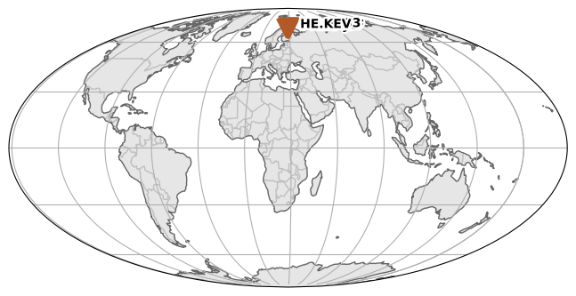

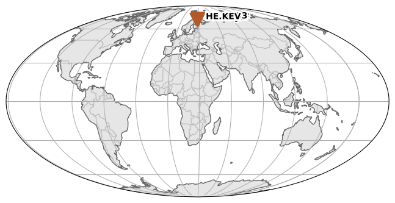

```python
OBSPY['Kola SG-3']['inventory'].plot()
```

Get the data!

```python
# inspect the inventory
OBSPY['Kola SG-3']['inventory']
```

```
Inventory created at 2025-11-12T14:43:44.371485Z
	Created by: ObsPy 1.4.2
		    https://www.obspy.org
	Sending institution: ObsPy FDSN Routing 1.4.2,SeisComP (GFZ,UIB-NORSAR)
	Contains:
		Networks (4):
			1G, FN, HE, NS
		Stations (7):
			1G.SA03 (Station Monteret, Norway)
			1G.SA09 (Station Svanvik, Norway)
			1G.SA10 (Station Mareveadji, Norway)
			FN.KMNF (SGO Station Inari, Kaamanen, Finland)
			FN.RAJF (SGO Station Inari, Raja-jooseppi, Finland)
			HE.KEV (Station Kevo, Finland)
			NS.VADS (Vadso, Norway)
		Channels (0):
```

```python
print(OBSPY['Kola SG-3']['inventory'][0])
```

```
Network NS (UIB)
	Station Count: None/None (Selected/Total)
	1980-01-01T00:00:00.000000Z - --
	Access: open
	Contains:
		Stations (1):
			NS.VADS (Vadso, Norway)
		Channels (0):
```

```python
# how does the object at network level look like?
dir(OBSPY['Kola SG-3']['inventory'][0])
```

```
['__class__',
 '__delattr__',
 '__dict__',
 '__dir__',
 '__doc__',
 '__eq__',
 '__format__',
 '__ge__',
 '__getattribute__',
 '__getitem__',
 '__getstate__',
 '__gt__',
 '__hash__',
 '__init__',
 '__init_subclass__',
 '__le__',
 '__len__',
 '__lt__',
 '__module__',
 '__ne__',
 '__new__',
 '__reduce__',
 '__reduce_ex__',
 '__repr__',
 '__setattr__',
 '__short_str__',
 '__sizeof__',
 '__slotnames__',
 '__str__',
 '__subclasshook__',
 '__weakref__',
 '_alternate_code',
 '_code',
 '_historical_code',
 '_identifiers',
 '_operators',
 '_repr_pretty_',
 '_selected_number_of_stations',
 '_source_id',
 '_stations',
```

[output cut: 11 more lines]

```
 'get_orientation',
 'get_response',
 'historical_code',
 'identifiers',
 'is_active',
 'operators',
 'plot',
 'plot_response',
 'restricted_status',
 'select',
 'selected_number_of_stations',
 'source_id',
 'start_date',
 'stations',
 'total_number_of_stations']
```

```python
# and how does the object at station level look like?
dir(OBSPY['Kola SG-3']['inventory'][0][0])
```

```
['__class__',
 '__delattr__',
 '__dict__',
 '__dir__',
 '__doc__',
 '__eq__',
 '__format__',
 '__ge__',
 '__getattribute__',
 '__getitem__',
 '__getstate__',
 '__gt__',
 '__hash__',
 '__init__',
 '__init_subclass__',
 '__le__',
 '__len__',
 '__lt__',
 '__module__',
 '__ne__',
 '__new__',
 '__reduce__',
 '__reduce_ex__',
 '__repr__',
 '__setattr__',
 '__sizeof__',
 '__slotnames__',
 '__str__',
 '__subclasshook__',
 '__weakref__',
 '_alternate_code',
 '_code',
 '_creation_date',
 '_elevation',
 '_equipments',
 '_external_references',
 '_historical_code',
 '_identifiers',
 '_latitude',
 '_longitude',
```

[output cut: 23 more lines]

```
 'is_active',
 'latitude',
 'longitude',
 'operators',
 'plot',
 'restricted_status',
 'select',
 'selected_number_of_channels',
 'site',
 'source_id',
 'start_date',
 'termination_date',
 'total_number_of_channels',
 'vault',
 'water_level']
```

```python
# get network and station codes for single inventory and check start and stop times of data acquisition
for network in OBSPY['Kola SG-3']['inventory']:
    for station in network:
        print(network.code + ', ' + station.code)
        print(station.start_date, station.end_date)
```

```
NS, VADS
2016-09-07T00:00:00.000000Z 2029-12-31T00:00:00.000000Z
FN, RAJF
2024-04-22T00:00:00.000000Z None
FN, KMNF
2024-04-22T00:00:00.000000Z None
1G, SA09
2013-09-23T00:00:00.000000Z 2016-05-09T00:00:00.000000Z
1G, SA10
2013-09-25T00:00:00.000000Z 2016-05-11T00:00:00.000000Z
1G, SA03
2012-08-03T00:00:00.000000Z 2017-08-31T00:00:00.000000Z
HE, KEV
1980-01-01T00:00:00.000000Z None
```

```python
# generalise for the dictionary and only list stations that are presently active
for borehole, content in OBSPY.items():
    for network in content['inventory']:
        for station in network:
            if not station.end_date:
                print(borehole)
                print('  Network:' + network.code)
                print('    Station:' + station.code, station.start_date, station.end_date)
                # print('      Channels:' + str(station.channels))
```

```
Outokumpu
  Network:HE
    Station:JOF 2006-01-01T00:00:00.000000Z None
Outokumpu
  Network:HE
    Station:SUF 2006-01-01T00:00:00.000000Z None
Outokumpu
  Network:HE
    Station:RUF 2016-09-21T00:00:00.000000Z None
Outokumpu
  Network:HE
    Station:NIF 2017-06-19T00:00:00.000000Z None
Kola SG-3
  Network:FN
    Station:RAJF 2024-04-22T00:00:00.000000Z None
Kola SG-3
  Network:FN
    Station:KMNF 2024-04-22T00:00:00.000000Z None
Kola SG-3
  Network:HE
    Station:KEV 1980-01-01T00:00:00.000000Z None
Iceland, IDDP-1-A, RN-17
  Network:VI
    Station:ADA 1998-09-19T00:00:00.000000Z None
Iceland, IDDP-1-A, RN-17
  Network:VI
    Station:GIL 1993-10-23T00:00:00.000000Z None
Iceland, IDDP-1-A, RN-17
  Network:VI
    Station:ISKR 1996-10-01T00:00:00.000000Z None
Iceland, IDDP-1-A, RN-17
  Network:VI
    Station:SKR 1996-10-02T00:00:00.000000Z None
COSC-1 A
  Network:UP
    Station:NOD 1999-09-07T12:00:00.000000Z None
COSC-2 A
  Network:UP
    Station:NOD 1999-09-07T12:00:00.000000Z None
```

```python
# get the data with client.get_waveforms("<network>","<station>","<location>","<channel>","<starttime>","<endtime>")
# not sure about location, we use all locations (instruments) "*"
# no channel information, we use all channels "*"
# test how to extract this information

active_stations = []

for borehole, content in OBSPY.items():
    for network in content['inventory']:
        for station in network:
            if not station.end_date:
                active_stations.append([network.code, station.code])
print(active_stations)
# create a list of tuples, make the tuples unique, and convert back to a list
unique_active_stations = [list(x) for x in set(tuple(x) for x in active_stations)]
print(unique_active_stations)
```

```
[['HE', 'JOF'], ['HE', 'SUF'], ['HE', 'RUF'], ['HE', 'NIF'], ['FN', 'RAJF'], ['FN', 'KMNF'], ['HE', 'KEV'], ['VI', 'ADA'], ['VI', 'GIL'], ['VI', 'ISKR'], ['VI', 'SKR'], ['UP', 'NOD'], ['UP', 'NOD']]
[['VI', 'SKR'], ['FN', 'KMNF'], ['VI', 'ADA'], ['HE', 'RUF'], ['HE', 'KEV'], ['VI', 'ISKR'], ['UP', 'NOD'], ['FN', 'RAJF'], ['HE', 'SUF'], ['VI', 'GIL'], ['HE', 'NIF'], ['HE', 'JOF']]
```

```python
tstart = UTCDateTime("2025-04-2T00:00:00.000")
tend = tstart + 6000
print("start time: " + str(tstart))
print("end time: " + str(tend))

for item in unique_active_stations:
    print("Network: " + item[0] + ", Station: " + item[1])
    data = client.get_waveforms(network=item[0], station=item[1], location="*", channel="*", starttime=tstart, endtime=tend)
    item.append(data)
    print(data)
```

```
start time: 2025-04-02T00:00:00.000000Z
end time: 2025-04-02T01:40:00.000000Z
Network: VI, Station: SKR
0 Trace(s) in Stream:

Network: FN, Station: KMNF
6 Trace(s) in Stream:
FN.KMNF..BHE | 2025-04-01T23:59:57.900000Z - 2025-04-02T01:40:12.350000Z | 20.0 Hz, 120290 samples
FN.KMNF..BHN | 2025-04-01T23:59:39.500000Z - 2025-04-02T01:40:13.750000Z | 20.0 Hz, 120686 samples
FN.KMNF..BHZ | 2025-04-01T23:59:41.900000Z - 2025-04-02T01:40:09.850000Z | 20.0 Hz, 120560 samples
FN.KMNF..HHE | 2025-04-01T23:59:56.470000Z - 2025-04-02T01:40:03.420000Z | 100.0 Hz, 600696 samples
FN.KMNF..HHN | 2025-04-01T23:59:58.430000Z - 2025-04-02T01:40:01.260000Z | 100.0 Hz, 600284 samples
FN.KMNF..HHZ | 2025-04-01T23:59:56.210000Z - 2025-04-02T01:40:03.140000Z | 100.0 Hz, 600694 samples
Network: VI, Station: ADA
3 Trace(s) in Stream:
VI.ADA..HHE | 2025-04-01T23:59:58.200000Z - 2025-04-02T01:40:01.030000Z | 100.0 Hz, 600284 samples
VI.ADA..HHN | 2025-04-01T23:59:56.040000Z - 2025-04-02T01:40:02.990000Z | 100.0 Hz, 600696 samples
VI.ADA..HHZ | 2025-04-01T23:59:56.780000Z - 2025-04-02T01:40:03.730000Z | 100.0 Hz, 600696 samples
Network: HE, Station: RUF
3 Trace(s) in Stream:
HE.RUF..HHE | 2025-04-01T23:59:58.584000Z - 2025-04-02T01:40:00.460000Z | 250.0 Hz, 1500470 samples
HE.RUF..HHN | 2025-04-01T23:59:59.812000Z - 2025-04-02T01:40:00.064000Z | 250.0 Hz, 1500064 samples
HE.RUF..HHZ | 2025-04-01T23:59:58.876000Z - 2025-04-02T01:40:00.888000Z | 250.0 Hz, 1500504 samples
Network: HE, Station: KEV
3 Trace(s) in Stream:
HE.KEV..HHE | 2025-04-01T23:59:57.580000Z - 2025-04-02T01:40:00.250000Z | 100.0 Hz, 600268 samples
HE.KEV..HHN | 2025-04-01T23:59:58.600000Z - 2025-04-02T01:40:01.310000Z | 100.0 Hz, 600272 samples
HE.KEV..HHZ | 2025-04-01T23:59:57.600000Z - 2025-04-02T01:40:00.430000Z | 100.0 Hz, 600284 samples
Network: VI, Station: ISKR
0 Trace(s) in Stream:

Network: UP, Station: NOD
3 Trace(s) in Stream:
UP.NOD..HHE | 2025-04-01T23:59:57.200000Z - 2025-04-02T01:40:01.090000Z | 100.0 Hz, 600390 samples
UP.NOD..HHN | 2025-04-01T23:59:57.540000Z - 2025-04-02T01:40:02.350000Z | 100.0 Hz, 600482 samples
UP.NOD..HHZ | 2025-04-01T23:59:58.890000Z - 2025-04-02T01:40:00.280000Z | 100.0 Hz, 600140 samples
Network: FN, Station: RAJF
6 Trace(s) in Stream:
FN.RAJF..BHE | 2025-04-01T23:59:45.250000Z - 2025-04-02T01:40:00.400000Z | 20.0 Hz, 120304 samples
FN.RAJF..BHN | 2025-04-01T23:59:41.950000Z - 2025-04-02T01:40:12.600000Z | 20.0 Hz, 120614 samples
```

[output cut: 9 more lines]

```
Network: VI, Station: GIL
3 Trace(s) in Stream:
VI.GIL..HHE | 2025-04-01T23:59:56.940000Z - 2025-04-02T01:40:03.890000Z | 100.0 Hz, 600696 samples
VI.GIL..HHN | 2025-04-01T23:59:56.840000Z - 2025-04-02T01:40:03.790000Z | 100.0 Hz, 600696 samples
VI.GIL..HHZ | 2025-04-01T23:59:58.020000Z - 2025-04-02T01:40:00.810000Z | 100.0 Hz, 600280 samples
Network: HE, Station: NIF
3 Trace(s) in Stream:
HE.NIF..HHE | 2025-04-01T23:59:59.428000Z - 2025-04-02T01:40:01.440000Z | 250.0 Hz, 1500504 samples
HE.NIF..HHN | 2025-04-01T23:59:59.208000Z - 2025-04-02T01:40:01.220000Z | 250.0 Hz, 1500504 samples
HE.NIF..HHZ | 2025-04-01T23:59:58.744000Z - 2025-04-02T01:40:00.756000Z | 250.0 Hz, 1500504 samples
Network: HE, Station: JOF
3 Trace(s) in Stream:
HE.JOF..HHE | 2025-04-01T23:59:56.430000Z - 2025-04-02T01:40:03.380000Z | 100.0 Hz, 600696 samples
HE.JOF..HHN | 2025-04-01T23:59:57.260000Z - 2025-04-02T01:40:00.090000Z | 100.0 Hz, 600284 samples
HE.JOF..HHZ | 2025-04-01T23:59:59.720000Z - 2025-04-02T01:40:02.550000Z | 100.0 Hz, 600284 samples
```

```
[
    '__add__',
    '__class__',
    '__delattr__',
    '__delitem__',
    '__dict__',
    '__dir__',
    '__doc__',
    '__eq__',
    '__format__',
    '__ge__',
    '__getattribute__',
    '__getitem__',
    '__getslice__',
    '__getstate__',
    '__gt__',
    '__hash__',
    '__iadd__',
    '__init__',
    '__init_subclass__',
    '__iter__',
    '__le__',
    '__len__',
    '__lt__',
    '__module__',
    '__mul__',
    '__ne__',
    '__new__',
    '__nonzero__',
    '__reduce__',
    '__reduce_ex__',
    '__repr__',
    '__setattr__',
    '__setitem__',
    '__sizeof__',
    '__str__',
    '__subclasshook__',
    '__weakref__',
    '_cleanup',
    '_dummy_stream_from_string',
```

[output cut: 37 more lines]

```
    'simulate',
    'slice',
    'slide',
    'sort',
    'spectrogram',
    'split',
    'stack',
    'std',
    'taper',
    'traces',
    'trigger',
    'trim',
    'verify',
    'write',
]
```

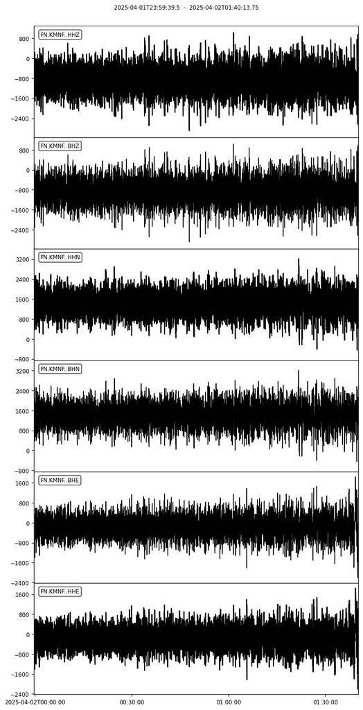

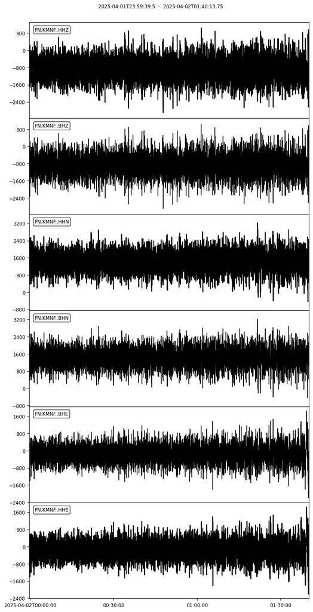

```python
pp(dir(unique_active_stations[0][2]))
unique_active_stations[1][2].plot()
```

Process the data, send the data to a computing e-infrastructure

or simply visualise the data as they are

Processing, visualisation  
Web map, integration of other data

Use Folium, a Python interface to Leaflet.js, to display stations and data

Compile list of station locations for the sizing of the background map (sizing works only in the notebook, not in the slides!)

```python
gmllist = []
lat_min = 90.00
lat_max = -90.00
lon_min = 180.00
lon_max = -180.00

# GML point to lat lon tuple
def latlonfromgmlpoint(gmlpoint):
    latlon = re.search(r"(\d{1,2}.\d{1,})\s(-{0,1}\d{1,2}.\d{1,})", gmlpoint)
    return latlon[1], latlon[2]

# borehole locations
for key, value in boreholes.items():
    gmllist.append(boreholes[key]['GML_location'])
# locations of GNSS stations
for key, value in boreholes.items():
    if 'GNSS' in boreholes[key]:
        for subkey, subvalue in boreholes[key]['GNSS'].items():
            gmllist.append(subvalue)
# locations of seismic stations
for key, value in boreholes.items():
    if 'SeisStation' in boreholes[key]:
        for subkey, subvalue in boreholes[key]['SeisStation'].items():
            for subsubkey, subsubvalue in subvalue.items():
                gmllist.append(subsubvalue)
# discard duplicate values
gmllist = set(gmllist)

# compile minimum and maximum values for latitude and longitude, add some boundary space
for item in gmllist:
    latlonitem = latlonfromgmlpoint(item)
    lat = float(latlonitem[0])
    lon = float(latlonitem[1])
    if lat > lat_max:
        lat_max = round(lat * 1.05, 4)
    if lat < lat_min:
        lat_min = round(lat * 0.95, 4)
    if lon > lon_max:
        lon_max = round(lon * 1.05, 4)
    if lon < lon_min:
        lon_min = round(lon * 0.95, 4)

pp(gmllist)
print(lat_max, lat_min, lon_max, lon_min)
```

```
set([
    'POINT(17.283 73.733)',
    'POINT(19.74 -155.05)',
    'POINT(34.41 118.67)',
    'POINT(35.97417 -120.55185)',
    'POINT(35.97426 -120.55211)',
    'POINT(37.3217 -75.9757)',
    'POINT(46.2408 125.36307)',
    'POINT(61.87355658240056 28.725577291922274)',
    'POINT(62.4195 13.5132)',
    'POINT(62.71781 29.06199)',
    'POINT(63.0414 13.9679)',
    'POINT(63.31245 13.52648)',
    'POINT(63.40163 13.20292)',
    'POINT(63.513508262634765 29.12036122650406)',
    'POINT(64.9337 -16.6756)',
    'POINT(64.9504 -16.924)',
    'POINT(65.64232099893643 -16.89135299692086)',
    'POINT(65.6945 -16.7749)',
    'POINT(65.71587 -16.76452)',
    'POINT(66.4611 -15.9467)',
    'POINT(69.17 29.28)',
])
72.6285 16.4188 131.25 -147.25
```

Set up a basic map with boreholes

```python
import folium

# define the map
map = folium.Map(location=[(lat_max + lat_min)/2,(lon_max + lon_min)/2], tiles="CartoDB positron")
map.fit_bounds([[lat_min,lon_min],[lat_max,lon_max]])

# add the borehole locations to the map
for key, value in boreholes.items():
    coord = latlonfromgmlpoint(boreholes[key]['GML_location'])
    bh_icon = folium.features.CustomIcon('https://raw.githubusercontent.com/daoane/epos-multidisciplinary-service-integration/refs/heads/main/images/Rigg_black_large.png', icon_size=(62,72), icon_anchor=(31,36),)
    bh_marker = folium.Marker(location=[coord[0],coord[1]], icon=bh_icon)
    bh_pop = folium.Popup(key)
    bh_marker.add_child(bh_pop)
    map.add_child(bh_marker)

# plot the map object
map
```

Make this Notebook Trusted to load map: File -> Trust Notebook

[interactive chart not shown]

Add GNSS stations

```python
# compile data for the markers
GNSSstations = {}
for key, value in boreholes.items():
    if 'GNSS' in boreholes[key]:
        for subkey, subvalue in boreholes[key]['GNSS'].items():
            coord = latlonfromgmlpoint(subvalue)
            if subkey in sensordata['GNSS']['positions10years']:
                timeseries = sensordata['GNSS']['positions10years'][subkey]
            else:
                timeseries = {}
            GNSSstations[subkey] = [coord[0], coord[1], timeseries]
```

```python
%%capture

# get rid of filter warnings, mainly with regard to deprecation warnings between packages
import warnings
warnings.filterwarnings("ignore", category=DeprecationWarning)

# import matplotlib to plot data for popups
import matplotlib.pyplot as plt

# import mpld3 converter to convert matplotlib figures to html string
import mpld3


# define the icon for GNSS stations
gnss_icon = folium.features.CustomIcon(
    'https://www.epos-eu.org/sites/default/files/2021-11/GNSS%20Data%20and%20Products%20v2.png',
    icon_size=(30,30),
    icon_anchor=(15, 15),
)

# define the plot function
def gnssplot(data):
    time = []
    data = json.loads(data)
    for t in data['domain']['axes']['t']['values']:
        time.append(datetime.fromisoformat(t.replace('Z', '+00:00')))
    e = data['ranges']['E']['values']
    n = data['ranges']['N']['values']
    u = data['ranges']['U']['values']
    fig = plt.figure(figsize=(5, 2))
    plt.plot(time, e, label='E', marker='.', markersize=1, linewidth=0.5)
    plt.plot(time, n, label='N', marker='.', markersize=1, linewidth=0.5)
    plt.plot(time, u, label='U', marker='.', markersize=1, linewidth=0.5)
    plt.xlabel('year')
    plt.ylabel('rel. dist. [mm]')
    plt.title(k)
    plt.legend()
    return fig


# if time series data are available, prepare the plot
for k,v in GNSSstations.items():
    if v[2] != {}:
        figure = gnssplot(v[2])
#define the data pop-up
        htmlplot = mpld3.fig_to_html(figure)
        iframe = folium.IFrame(htmlplot, width=525, height=225)
        popup = folium.Popup(iframe, max_width=2650)

    else:
        popup = folium.Popup(k)

# define the marker
    gnss_marker = folium.Marker(location=[v[0],v[1]], icon=gnss_icon, popup=popup)

# add the marker to the map
    map.add_child(gnss_marker)
```

```python
# call the map object
map
```

Make this Notebook Trusted to load map: File -> Trust Notebook

[interactive chart not shown]

Add seismic stations that have data (first case with dictionaries)

```python
%%capture

# compile data for the markers
stations = []
for key, value in boreholes.items():
    if 'SeisStation' in boreholes[key]:
        for subkey, subvalue in boreholes[key]['SeisStation'].items():
            for subsubkey, subsubvalue in subvalue.items():
                coord = latlonfromgmlpoint(subsubvalue)
                if subsubkey in sensordata['Seismic']['waveforms']:
                    stations.append((subsubkey,coord[0],coord[1]))
stations = set(stations)

for item in stations:
# define the icon for seismic stations
    seis_icon = folium.features.CustomIcon(
        'https://www.epos-eu.org/sites/default/files/2021-11/Seismology%20v2.png',
        icon_size=(30,30),
        icon_anchor=(15, 15),
    )

#define the data pop-up
    htmlplot = mpld3.fig_to_html(sensordata['Seismic']['waveforms'][item[0]][next(iter(sensordata['Seismic']['waveforms'][item[0]]))].plot())
    iframe = folium.IFrame(htmlplot, width=840, height=290)
    popup = folium.Popup(iframe, max_width=2650)

# define the marker
    seis_marker = folium.Marker(location=[item[1],item[2]], icon=seis_icon, popup=popup)

# add the marker to the map
    map.add_child(seis_marker)
```

```python
# call the map object
map
```

Make this Notebook Trusted to load map: File -> Trust Notebook

[interactive chart not shown]

Add data from a local resource ("own" or "other research data")

International database of Glacially Induced Faults (Munier et al. 2020)

```python
# Commented out, as data were already downloaded in the explanatory section above
## Create data directory, if it does not exist
#if not os.path.exists('./data'):
#   os.makedirs('./data')
## use geopandas to read/convert diverse common geodata formats
import geopandas
#
## download data from PANGAEA database, dataset https://doi.org/10.1594/PANGAEA.922705 and unpack the shape file into the working directory
#getfile = urllib.request.urlretrieve("https://download.pangaea.de/dataset/922705/files/Glacially-Induced_Faults.zip", "./data/Glacially-Induced_Faults.zip")
#with zipfile.ZipFile('./data/Glacially-Induced_Faults.zip', 'r') as zip_ref:
#    zip_ref.extractall(path="./data")
## read the shape file and display it
gif = geopandas.read_file("./data/GIF.shp")
folium.GeoJson(gif, style_function=lambda x:{'color': 'red'}, tooltip=folium.GeoJsonTooltip(fields=['Complex_na'])).add_to(map)

# call the map object
map
```

Make this Notebook Trusted to load map: File -> Trust Notebook

[interactive chart not shown]